# R Notebook

```r
library(clusterProfiler)
library(DOSE)
library(ReactomePA)
library(tidyverse)
library(readxl)
setwd("~/AA_PostDoc/human-metnet/results/stimulated_NAMU_results_analysis/functional_analysis_of_hubs")

c('PGM', 'ACYP', 'PGI', 'PGK','PYK', 'HEX1', 'DPGase', 'TPI', 'PFK', 'ENO', 'GAPD', 'DPGM', 'FBA', 'G3PD2m' ,
'ACYP_Neuron', 'DPGM_Neuron', 'DPGase_Neuron', 'ENO_Neuron', 'FBA_Neuron', 'G3PD2m_Neuron', 'GAPD_Neuron', 'HEX1_Neuron', 'PFK_Neuron', 'PGI_Neuron', 'PGK_Neuron', 'PGM_Neuron', 'PYK_Neuron', 'TPI_Neuron' ,
'ATPS4m_Neuron', 'CYOOm2_Neuron', 'CYOR-u10m_Neuron', 'NADH2-u10m_Neuron', 'PPA_Neuron', 'PPAm_Neuron' ,
'PPAm', 'ATPS4m', 'CYOOm2', 'CYOR-u10m', 'NADH2-u10m', 'PPA', 'GLCt1r', 'GLCt1r_Neuron', 'GLCt2r') -> subsystems
filter_out_subsystems <- function(df){df[!(df$ID %in% subsystems),]}
get_genes_from_module <- function(hubs){     hubs %>%
                                             dplyr::select(matches('gene')) %>% purrr::reduce(c) %>% na.exclude() %>% str_c(collapse = ", ") %>%
                                            str_split(pattern=",") %>%str_extract_all('\\d+') %>% unlist() %>% str_trim %>% unique()}
```

### NEURON

```r
cut_off_optimality <-0.01  # 0.01
cut_off_centrality <- 0.01 # 0.01
central_hubs <- readxl::read_excel('Neuron_IDs_centrality_optimality.xlsx')%>% dplyr::select(-"Optimality")%>%filter(Centrality > cut_off_centrality)%>% filter_out_subsystems
optimal_hubs <- readxl::read_excel('Neuron_IDs_centrality_optimality.xlsx')%>% dplyr::select(-"Centrality")%>%filter(Optimality > cut_off_optimality)%>% filter_out_subsystems
central_hubs %<>%  get_genes_from_module
optimal_hubs %<>%  get_genes_from_module
intersect(central_hubs, optimal_hubs) -> hyper_hubs
setdiff(central_hubs,hyper_hubs) -> central_hubs
setdiff(optimal_hubs,hyper_hubs) -> optimal_hubs
list(optimal_hubs, central_hubs, hyper_hubs)  %>% purrr::set_names(c("Optimal", "Central", "Hyper"))  -> hubs
intersect(central_hubs, optimal_hubs)
```

```
character(0)
```

```r
intersect(central_hubs, hyper_hubs)
```

```
character(0)
```

```r
intersect(optimal_hubs, hyper_hubs)
```

```
character(0)
```

```r
hubs %>% glimpse()
```

```
List of 3
 $ Optimal: chr [1:16] "50" "48" "8402" "1468" ...
 $ Central: chr [1:57] "8659" "217" "212" "23464" ...
 $ Hyper  : chr [1:147] "219" "9194" "6566" "3712" ...
```

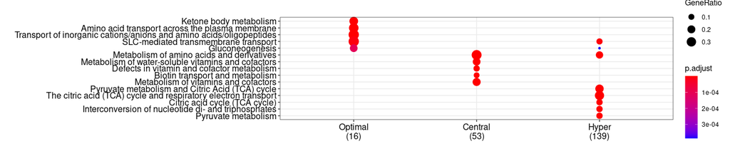

```r
compareCluster(hubs, fun='enrichPathway', pvalueCutoff=1e-3) -> clusters_plot; clusters_plot %>% dotplot
```

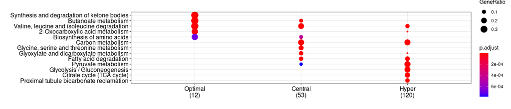

```r
compareCluster(hubs, fun='enrichKEGG', pvalueCutoff=1e-3) %>% dotplot
```

## ASTROCYTE

```r
cut_off_optimality <-0.01  # 0.01
cut_off_centrality <- 0.01 # 0.01
central_hubs <- readxl::read_excel('Astrocyte_IDs_centrality_optimality.xlsx')%>% dplyr::select(-"Optimality")%>%filter(Centrality > cut_off_centrality)%>% filter_out_subsystems
optimal_hubs <- readxl::read_excel('Astrocyte_IDs_centrality_optimality.xlsx')%>% dplyr::select(-"Centrality")%>%filter(Optimality > cut_off_optimality)%>% filter_out_subsystems


central_hubs %<>%  get_genes_from_module
optimal_hubs %<>%  get_genes_from_module
intersect(central_hubs, optimal_hubs) -> hyper_hubs
setdiff(central_hubs,hyper_hubs) -> central_hubs
setdiff(optimal_hubs,hyper_hubs) -> optimal_hubs
list(optimal_hubs, central_hubs, hyper_hubs)  %>% purrr::set_names(c("Optimal", "Central", "Hyper"))  -> hubs
intersect(central_hubs, optimal_hubs)
```

```
character(0)
```

```r
intersect(central_hubs, hyper_hubs)
```

```
character(0)
```

```r
intersect(optimal_hubs, hyper_hubs)
```

```
character(0)
```

```r
hubs %>% glimpse()
```

```
List of 3
 $ Optimal: chr [1:4] "56301" "8140" "3155" "54511"
 $ Central: chr [1:308] "55268" "2805" "2806" "65985" ...
 $ Hyper  : chr [1:147] "1591" "1594" "4967" "1738" ...
```

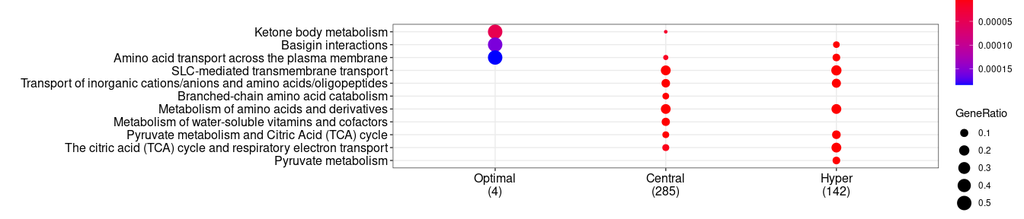

```r
compareCluster(hubs, fun='enrichPathway', pvalueCutoff=1e-3) -> clusters_plot; clusters_plot %>% dotplot
```

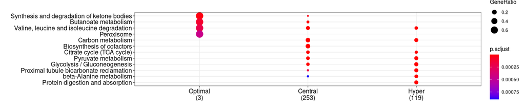

```r
compareCluster(hubs, fun='enrichKEGG', pvalueCutoff=1e-3) %>% dotplot
```

Functions

```r
get_genes_from_each_hub <- function(file, cut_off_optimality = 0.01 , cut_off_centrality =  0.01){

central_hubs <- readxl::read_excel(file)%>% dplyr::select(-"Optimality")%>%filter(Centrality > cut_off_centrality)%>% filter_out_subsystems
optimal_hubs <- readxl::read_excel(file)%>% dplyr::select(-"Centrality")%>%filter(Optimality > cut_off_optimality)%>% filter_out_subsystems

central_optimal_hubs <-  readxl::read_excel(file)%>% filter_out_subsystems

intersect(central_hubs$ID, optimal_hubs$ID) -> hyper_IDs
setdiff(central_hubs$ID,hyper_IDs)          -> central_IDs
 setdiff(optimal_hubs$ID,hyper_IDs)         -> optimal_IDs

central_hubs         %>% filter(ID %in% central_IDs) %>%  get_genes_from_module -> central_hub_genes
optimal_hubs         %>% filter(ID %in% optimal_IDs) %>%  get_genes_from_module -> optimal_hub_genes
central_optimal_hubs %>% filter(ID %in% hyper_IDs) %>% get_genes_from_module -> hyper_hub_genes

list_of_genes_by_hubs <- list(optimal_hub_genes,central_hub_genes,hyper_hub_genes) %>% set_names(c('optimal_hub_genes','central_hub_genes','hyper_hub_genes'))

return(list_of_genes_by_hubs)

}


get_pure_gene_groups <- function(list_of_genes_by_hubs){

  list_of_genes_by_hubs$optimal_hub_genes -> optimal_hub_genes
  list_of_genes_by_hubs$central_hub_genes ->central_hub_genes
  list_of_genes_by_hubs$hyper_hub_genes ->hyper_hub_genes


Type_5                <- Reduce(intersect, list(central_hub_genes,optimal_hub_genes,  hyper_hub_genes))
Type_4_hyper_optimal  <-  Reduce(intersect, list(optimal_hub_genes,  hyper_hub_genes))
Typer_4_hyper_central <- Reduce(intersect, list(central_hub_genes,  hyper_hub_genes))
Type_3                <- setdiff(hyper_hub_genes, c(Type_5, Type_4_hyper_optimal, Typer_4_hyper_central) )
Type_2                <-  Reduce(intersect, list(central_hub_genes,optimal_hub_genes))
Type_1_optimal        <-  setdiff(optimal_hub_genes, c(Type_2, Type_3, Typer_4_hyper_central, Type_4_hyper_optimal, Type_5) )
Type_1_central        <-  setdiff(central_hub_genes, c(Type_2, Type_3, Typer_4_hyper_central, Type_4_hyper_optimal, Type_5) )

list(Type_1_optimal, Type_1_central, Type_2, Type_3, Type_4_hyper_optimal, Typer_4_hyper_central, Type_5) %>%
  set_names('Type_1_optimal', 'Type_1_central', 'Type_2', 'Type_3', 'Type_4_hyper_optimal', 'Typer_4_hyper_central', 'Type_5') -> my_list
# sanity check
c(optimal_hub_genes, central_hub_genes, hyper_hub_genes) %>% unique() -> all_genes
all((Reduce(c, gene_groups) %in% all_genes) & (all_genes %in% Reduce(c, gene_groups)) ) -> sanity_check

if (sanity_check){message('all classified')}

return(my_list)
}
```

#Non-overlapping gene groups:

#NEURON ranked by pure genes

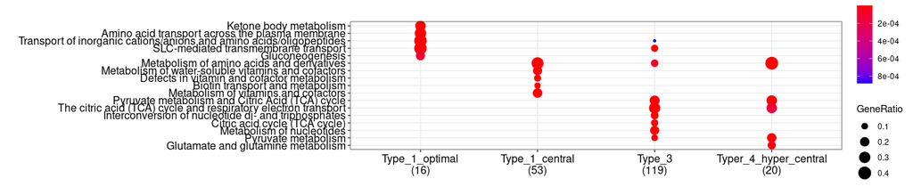

```r
get_genes_from_each_hub('Neuron_IDs_centrality_optimality.xlsx') -> list_of_genes_by_hubs
get_pure_gene_groups(list_of_genes_by_hubs) -> gene_groups
gene_groups %>%compareCluster(fun='enrichPathway', pvalueCutoff=1e-3)  %>% dotplot
```

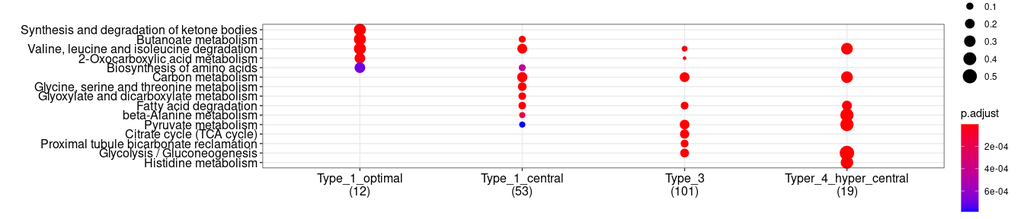

```r
gene_groups %>%compareCluster(fun='enrichKEGG', pvalueCutoff=1e-3) %>% dotplot
```

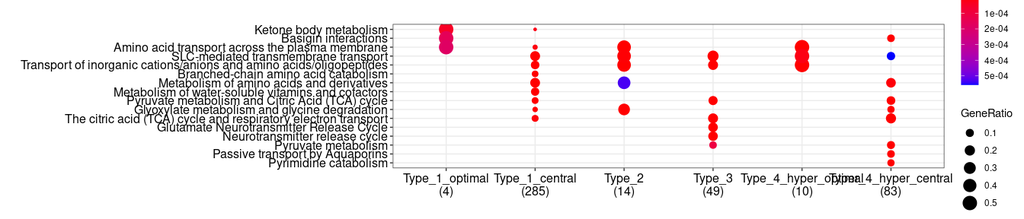

```r
get_genes_from_each_hub('Astrocyte_IDs_centrality_optimality.xlsx') -> list_of_genes_by_hubs
get_pure_gene_groups(list_of_genes_by_hubs) -> gene_groups
gene_groups %>%compareCluster(fun='enrichPathway', pvalueCutoff=1e-3)  %>% dotplot
```

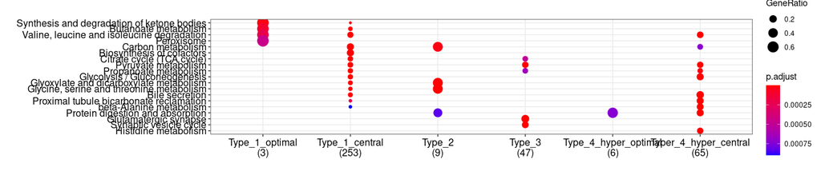

```r
gene_groups %>%compareCluster(fun='enrichKEGG', pvalueCutoff=1e-3) %>% dotplot
```

```r
cut_off_optimality <-0.01  # 0.01
cut_off_centrality <- 0.01 # 0.01
central_hubs <- readxl::read_excel('Astrocyte_IDs_centrality_optimality.xlsx')%>% dplyr::select(-"Optimality")%>%filter(Centrality > cut_off_centrality)%>% filter_out_subsystems
optimal_hubs <- readxl::read_excel('Astrocyte_IDs_centrality_optimality.xlsx')%>% dplyr::select(-"Centrality")%>%filter(Optimality > cut_off_optimality)%>% filter_out_subsystems

central_optimal_hubs <-  readxl::read_excel('Astrocyte_IDs_centrality_optimality.xlsx')%>% filter_out_subsystems

intersect(central_hubs$ID, optimal_hubs$ID) -> hyper_IDs
setdiff(central_hubs$ID,hyper_IDs) -> central_IDs
 setdiff(optimal_hubs$ID,hyper_IDs) -> optimal_IDs

central_hubs         %>% filter(ID  %in%  central_IDs ) %>%  get_genes_from_module -> central_genes
optimal_hubs         %>% filter(ID  %in%  optimal_IDs) %>%  get_genes_from_module -> optimal_genes
central_optimal_hubs %>% filter(ID  %in% hyper_IDs) %>% get_genes_from_module -> hyper_genes

intersect(central_genes,optimal_genes)
```

```
 [1] "1738"   "6520"   "2653"   "275"    "2731"   "6541"   "6542"   "84889"  "11254"  "57393"  "59272"  "340024" "366"    "1"
```

```r
intersect(central_genes,hyper_genes)
```

```
 [1] "4967"   "1738"   "1743"   "8050"   "18"     "64902"  "8659"   "9194"   "6566"   "9123"   "23539"  "682"    "8854"   "501"    "224"    "223"    "216"    "219"    "217"    "221"
[21] "220"    "218"    "222"    "80704"  "6510"   "2109"   "2108"   "2110"   "2168"   "2356"   "5244"   "5832"   "4329"   "7915"   "2746"   "2747"   "10165"  "8604"   "343"    "4284"
[41] "362"    "361"    "358"    "359"    "1591"   "1594"   "6515"   "56953"  "30833"  "4907"   "84618"  "22978"  "51251"  "93034"  "51205"  "54"     "55"     "53"     "23439"  "476"
[61] "481"    "480"    "478"    "477"    "482"    "483"    "57194"  "10396"  "7084"   "7083"   "11254"  "57393"  "59272"  "340024" "2992"   "2997"   "8908"   "2998"   "366"    "7352"
[81] "9016"   "9481"   "57084"  "3939"   "3945"   "1"
```

```r
intersect(optimal_genes,hyper_genes)
```

```
 [1] "1738"   "11254"  "57393"  "59272"  "54407"  "340024" "81539"  "55089"  "366"    "1"
```

```r
hubs_rxn_based <- list(optimal_genes, central_genes, hyper_genes)  %>% purrr::set_names(c("Optimal", "Central", "Hyper"))
hubs_rxn_based %>% glimpse()
```

```
List of 3
 $ Optimal: chr [1:21] "6520" "56301" "8140" "1738" ...
 $ Central: chr [1:400] "4967" "1738" "1743" "8050" ...
 $ Hyper  : chr [1:153] "1591" "1594" "18" "64902" ...
```

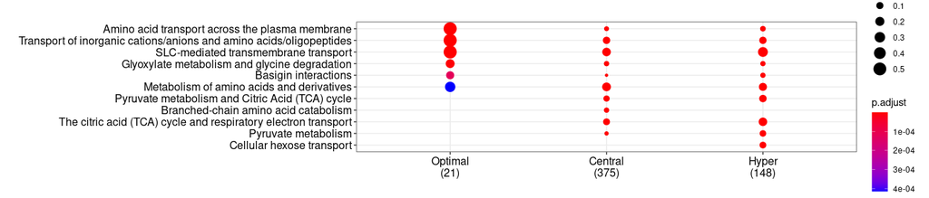

```r
compareCluster(hubs_rxn_based, fun='enrichPathway', pvalueCutoff=1e-3)  %>% dotplot
```

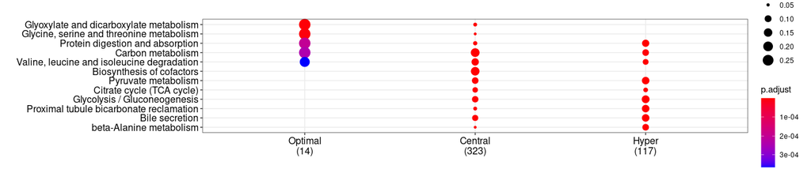

```r
compareCluster(hubs_rxn_based, fun='enrichKEGG', pvalueCutoff=1e-3) %>% dotplot
```

ketone bodies: BDHm (R)-3-Hydroxybutanoate:NAD+ Oxidoreductase bhb[m] + nad[m] <=> acac[m] + h[m] + nadh[m] genes: 56898(BDH2) 622(BDH1)

OCOAT1m 3-Oxoacid Coa-Transferase acac[m] + succoa[m] -> aacoa[m] + succ[m] genes: 5019(OXCT1) 64064(OXCT2)

AACOAT Acetoacetyl Coenzyme A:Acetate Coa-Transferase acac[c] + atp[c] + coa[c] -> aacoa[c] + amp[c] + ppi[c]: genes: 65985(AACS)

HMGLm Hydroxymethylglutaryl Coenzyme A Lyase hmgcoa[m] -> acac[m] + accoa[m] genes: 3155(HMGCL) 54511(HMGCLL1)

ACACT1rm Acetyl Coenzyme A C-Acetyltransferase, Mitochondrial 2.0 accoa[m] -> aacoa[m] + coa[m]

HMGCOASim Hydroxymethylglutaryl Coenzyme A Synthase (Ir) aacoa[m] + accoa[m] + h2o[m] -> coa[m] + h[m] + hmgcoa[m] genes: 3157(HMGCS1) 3158(HMGCS2)

CSm Citrate Synthase accoa[m] + h2o[m] + oaa[m] -> cit[m] + coa[m] + h[m] genes: 1431(CS)

ACSm Acetyl Coenzyme A Synthetase ac[m] + atp[m] + coa[m] -> accoa[m] + amp[m] + ppi[m] genes: 23181(DIP2A) 55902(ACSS2) 84532(ACSS1)

glutamate - akg: GLUDxm Glutamate Dehydrogenase (NAD), Mitochondrial glu_L[m] + h2o[m] + nad[m] <=> akg[m] + h[m] + nadh[m] + nh4[m] genes: 2746(GLUD1) 2747(GLUD2) AKGDm 2-oxoglutarate dehydrogenase Astrocyte akg[mA] + coa[mA] + nad[mA] –> co2[mA] + nadh[mA] + succoa[mA] genes: (4967.2 and 1738.1 and 8050.1 and 1743.1) or (4967.1 and 1738.1 and 8050.1 and 1743.1)

gluthatione: GLYOXm Hydroxyacylglutathione Hydrolase, Mitochondrial h2o[m] + lgt_S[m] -> gthrd[m] + h[m] + lac_D[m] genes: 3029(HAGH) GTHO Glutathione Oxidoreductase gthox[c] + h[c] + nadph[c] -> 2.0 gthrd[c] + nadp[c] genes: 2936(GSR)

```r
interesting_genes <- "BDHm|OCOAT1m|AACOAT|HMGLm|ACACT1rm|HMGCOASim|CSm|ACSm|GLUDxm|AKGDm|GLYOXm|GTHO"
H  %>% filter(str_detect(ID, regex(interesting_genes,ignore_case = T)))
C %>% filter(str_detect(ID, regex(interesting_genes,ignore_case = T)))
O %>% filter(str_detect(ID, regex(interesting_genes,ignore_case = T)))
```

[output not shown]

```r
H %>% writexl::write_xlsx("hyper_genes_rxns_df_aa.xlsx")
C %>%writexl::write_xlsx("central_genes_rxns_df_aa.xlsx")
O %>%writexl::write_xlsx("optimal_genes_rxns_df_aa.xlsx")
```

```r
H %>% dplyr::select(matches('gene')) %>% c %>% unlist %>% paste0%>% str_extract("\\d+") %>% na.omit() %>% as.character() -> H_only_genes
C%>% dplyr::select(matches('gene')) %>% c %>% unlist %>% paste0%>% str_extract("\\d+") %>% na.omit() %>% as.character() -> C_only_genes
O%>% dplyr::select(matches('gene')) %>% c %>% unlist %>% paste0%>% str_extract("\\d+") %>% na.omit() %>% as.character() -> O_only_genes


intersect(H_only_genes,C_only_genes )
intersect(H_only_genes,O_only_genes )
intersect(C_only_genes,O_only_genes )
```